# Визуализация биомедицинских данных. Домашнее задание

# О задании

В этом задании почти соблюдаются принципы классицизма: одно задание — не меньше одного графика и не меньше одного чанка, если не сказано иное. Правило действует, даже когда задание просит вернуться к предыдущему графику. При этом вы всегда можете расширить интерпретацию или показать то же самое ещё и другим, более подходящим, на ваш взгляд, способом — дополнительными графиками к заданию. Некоторые пункты касаются того, о чём на занятиях прямо не говорили, и потребуют справки и документации; обычно такие места оговорены в условии явно.

Инструкция по сдаче задания указана в `README.md` и на Stepik

## **Общие требования к оформлению**

1. Старайтесь соблюдать единый стиль оформления и структуру отчёта, если в задании не указано иное. Не оставляйте в финальном отчёте лишние чанки кода, текст или комментарии, которые не относятся к решению задания.
2. Любой output должен быть читаемым и достаточно кратким, чтобы было удобно просматривать. Не оставляйте «полотна» текста или вывода. Объёмный output оформите аккуратно, либо сократите, либо вовсе уберите. Таблицы оформляйте c пмощью flextable, а для графиков подбирайте подходящий размер и пропорции
3. Ответы на вопросы оформляйте в виде текста явно, не в виде комментариев к коду.
4. Сохраняйте исходную структуру проекта в репозитории. Не добавляйте лишние файлы, которые не относятся к проекту или выполнению заданий.
5. Оформление коммитов и веток на GitHub должно соответствовать общим правилам для всех курсов Института биоинформатики (см. соответствующий материал на курсе Python).

# Правила и требования для всех задач *в этом домашней задании*

**Выполняйте их, даже если в тексте задания они не упомянуты.**

- Под каждым графиком напишите интерпретацию: что на нём видно и какой вывод из этого следует, в 2–4 предложениях. Перечисление геомов и цветов интерпретацией не считается. Если вывода нет или данных для него мало, так и напишите.
- Делайте текст на графике настолько крупным, насколько позволяют сам график и ваше чувство меры. Читаемые надписи — важный (но не так уж часто встречающийся) элемент графиков.
- Не используйте фон ggplot2 по умолчанию.
- У каждого графика должен быть заголовок, отражающий его суть, и правильно названные оси.
- Все подписи на графиках — на русском языке.
- Старайтесь, чтобы графики были достаточно крупными и читались не только в отрендеренном HTML, но и при интерактивном запуске чанков в Positron.
- Однотипные графики стройте функцией (конспект 2, раздел «П6 · Функция для однотипных графиков (слайд П6)»).
- Цвета факультетов — как в конспектах: Гриффиндор `#B32025`, Хаффлпафф `#D7A900`, Рейвенкло `#2E5EAA`, Слизерин `#2F7D4A`. В задании 10 цвета берите с образца.

Для некоторых заданий понадобится пакет patchwork: он собирает несколько графиков в один (конспект 2, раздел «П9 · Несколько графиков на одну страницу (слайд П9)»). Советуем почитать его документацию и пользоваться им в домашней работе. Для задания 8 нужен пакет gghighlight. Если каких-то пакетов нет, установите их один раз в консоли: `install.packages(c("patchwork", "gghighlight"))`.

Если, пока вы строите и интерпретируете график, у вас появилась гипотеза, не стесняйтесь её проверить: постройте для того же задания ещё один график (или несколько), проведите дополнительное исследование.

# Подготовка

```r
library(tidyverse)
library(patchwork)
library(gghighlight)

hogwarts <- read_csv("data/hogwarts_2026.csv", show_col_types = FALSE)
```

# Задание 1

Постройте барплот (столбчатую диаграмму), отражающий распределение числа студентов по курсам обучения. Раскрасьте столбики любым понравившимся цветом: подойдёт и название цвета, и hex-код. Задайте и цвет контура столбиков. Проинтерпретируйте график.

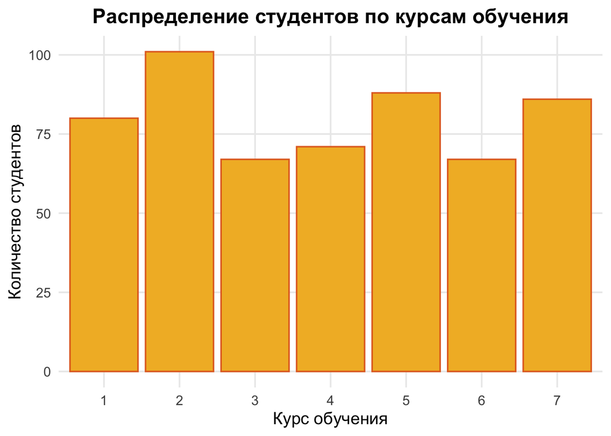

```r
ggplot(hogwarts, aes(x = factor(course))) +
  geom_bar(fill = "#F2B82E", color = "#E26D27", linewidth = 0.6) +
  labs(
    title = "Распределение студентов по курсам обучения",
    x = "Курс обучения",
    y = "Количество студентов"
  ) +
  theme_minimal(base_size = 14) +
  theme(
    plot.title = element_text(face = "bold", hjust = 0.5),
    panel.grid.minor = element_blank()
  )
```

**Интерпретация:** … На бар плоте видно что больше всего студентов 2го курса, а меньше всего на 3ем. Кроме того на 3, 4 и 6 курсы, а также 5 и 7 разбиваются на 2 подгруппы с более-менее одинаковым количеством студентов.

# Задание 2

Постройте новый барплот, отражающий распределение числа студентов по факультетам. Добавьте на график вторую факторную переменную — происхождение (`bloodStatus`).

С помощью аргумента `position` измените график так, чтобы каждый столбец показывал распределение факультета по чистоте крови в долях. Запишите текстом в этом файле, какой вывод можно сделать из графика.

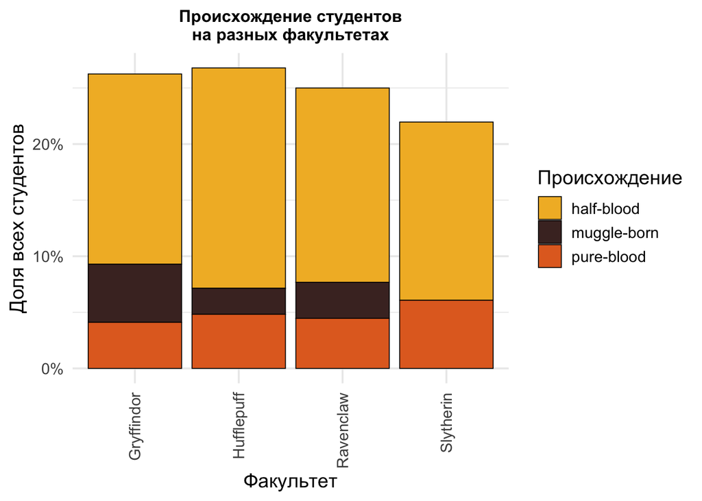

```r
ggplot(hogwarts, aes(x = house, fill = bloodStatus)) +
  geom_bar(
    aes(y = after_stat(count / sum(count))),
    position = "stack",
    color = "black",
    linewidth = 0.3
  ) +
  labs(
    title = "Происхождение студентов\nна разных факультетах",
    x = "Факультет",
    y = "Доля всех студентов",
    fill = "Происхождение"
  ) +
  scale_y_continuous(
    labels = scales::label_percent()
  ) +
  scale_fill_manual(
    values = c(
      "pure-blood" = "#E26D27",
      "half-blood" = "#F2B82E",
      "muggle-born" = "#4A2E2B"
    )
  ) +
  theme_minimal(base_size = 14) +
  theme(
    plot.title = element_text(face = "bold", hjust = 0.5, size = 12),
    axis.text.x = element_text(angle = 90, vjust = 0.5, hjust = 1)
  )
```

**Вывод:** … Меньше всего Слизеринцев, больше всего Хафлпаф, хотя большой разницы между ним, Гриффиндором и Когтевраном нет. Среди слизеринцев нет маглорожденных и больше всех чистокровок. В гриффиндоре больше, чем среди остальных, маглорожденных и меньше чистокровных.

# Задание 3

Отобразите распределение баллов, заработанных студентами на 3-й неделе обучения, по факультетам. Постарайтесь показать одновременно и форму распределения, и некоторые описательные статистики. Отсортируйте факультеты в порядке убывания медианного балла за 3-ю неделю (функция, которую мы разбирали на слайде 21, по умолчанию сортирует именно по медиане, так что задавать медиану отдельным аргументом не нужно). Если используете `geom_jitter()`, постарайтесь, чтобы точки лежали кучнее вдоль оси, которая не отражает само распределение. Проинтерпретируйте график.

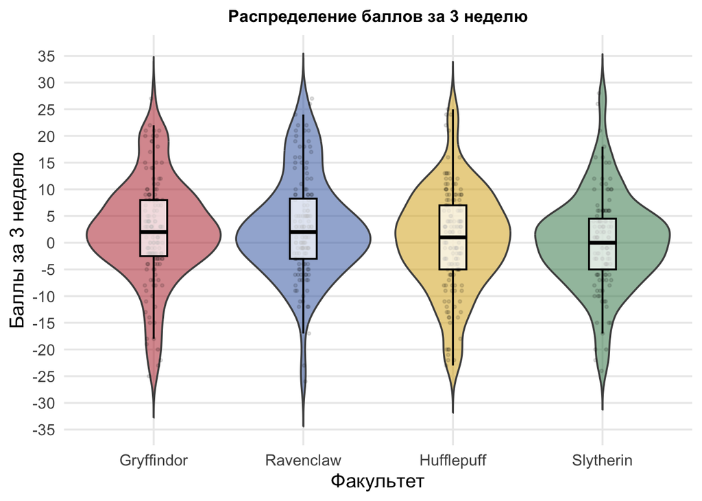

```r
ggplot(
  hogwarts,
  aes(x = house, y = week_3, fill = house)
) +
  geom_violin(
    trim = FALSE,
    alpha = 0.5,
    color = "grey30"
  ) +
  geom_jitter(
    width = 0.06,
    height = 0,
    alpha = 0.12,
    size = 0.7
  ) +
  geom_boxplot(
    width = 0.18,
    outlier.shape = NA,
    fill = "white",
    color = "black",
    alpha = 0.7
  ) +
  scale_fill_manual(
    values = c(
      "Gryffindor" = "#B32025",
      "Hufflepuff" = "#D7A900",
      "Ravenclaw" = "#2E5EAA",
      "Slytherin" = "#2F7D4A"
    )
  ) +
  scale_x_discrete(
    limits = hogwarts |>
      dplyr::group_by(house) |>
      dplyr::summarise(
        медиана = median(week_3, na.rm = TRUE),
        .groups = "drop"
      ) |>
      dplyr::arrange(desc(медиана)) |>
      dplyr::pull(house)
  ) +
  labs(
    title = "Распределение баллов за 3 неделю",
    x = "Факультет",
    y = "Баллы за 3 неделю"
  ) +
  scale_y_continuous(
    breaks = scales::breaks_width(5)
  ) +
  theme_minimal(base_size = 14) +
  theme(
    plot.title = element_text(
      face = "bold",
      hjust = 0.5,
      size = 12
    ),
    legend.position = "none",
    panel.grid.minor = element_blank()
  )
```

**Интерпретация:** … Чаще всего студентам добовляют, или им снимают, небольшие баллы (от -5 до 5). Однако Грифиндору часто дают до 10 баллов, а Пуффендую и Слизерину реже дают высокие баллы (15-25). Однако Пуффендую, в отличие от Слизерина чаще дают средние баллы (5-15). Медиана у всех факультетов более-менее одинаковая.

# Задание 4

Постройте гистограмму результатов любого экзамена на ваш выбор, кроме зельеварения. Настройте оптимальное, на ваш взгляд, число столбцов гистограммы. Выполните фасетирование по курсу. Постарайтесь, чтобы график был по возможности компактным. Проинтерпретируйте график.

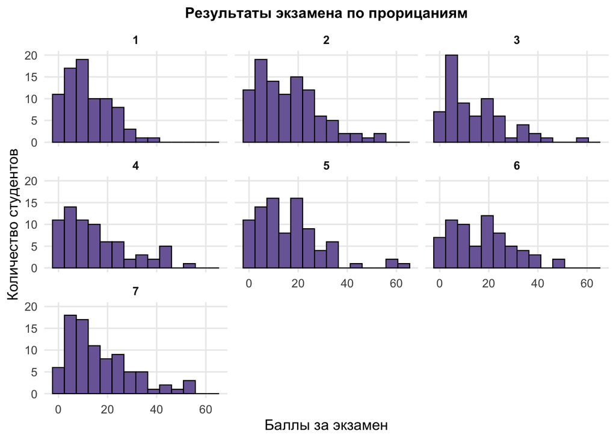

```r
ggplot(hogwarts, aes(x = `Divinations exam`)) +
  geom_histogram(
    bins = 14,
    fill = "#7B68A6",
    color = "black",
    linewidth = 0.4
  ) +
  facet_wrap(~ course, ncol = 3) +
  labs(
    title = "Результаты экзамена по прорицаниям",
    x = "Баллы за экзамен",
    y = "Количество студентов"
  ) +
  theme_minimal(base_size = 12) +
  theme(
    plot.title = element_text(face = "bold", hjust = 0.5, size = 12),
    strip.text = element_text(face = "bold"),
    panel.grid.minor = element_blank()
  )
```

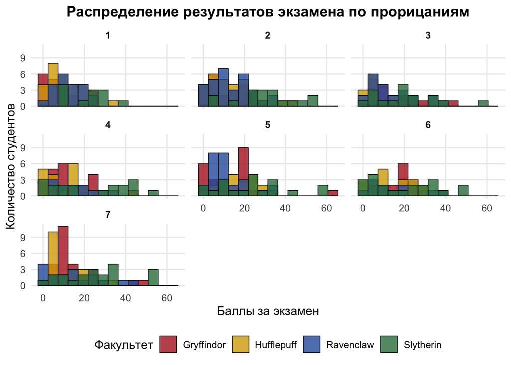

```r
ggplot(hogwarts, aes(x = `Divinations exam`, fill = house)) +
  geom_histogram(
    bins = 14,
    color = "black",
    linewidth = 0.3,
    alpha = 0.8,
    position = "identity"
  ) +
  facet_wrap(~ course, ncol = 3) +
  scale_fill_manual(
    values = c(
      "Gryffindor" = "#B32025",
      "Hufflepuff" = "#D7A900",
      "Ravenclaw" = "#2E5EAA",
      "Slytherin" = "#2F7D4A"
    ),
    name = "Факультет"
  ) +
  labs(
    title = "Распределение результатов экзамена по прорицаниям",
    x = "Баллы за экзамен",
    y = "Количество студентов"
  ) +
  theme_minimal(base_size = 12) +
  theme(
    plot.title = element_text(face = "bold", hjust = 0.5),
    strip.text = element_text(face = "bold"),
    panel.grid.minor = element_blank(),
    legend.position = "bottom"
  )
```

# Задание 5

Постройте скаттерплот, показывающий связь между суммарным баллом студента за год и оценкой за экзамен (по травологии, магловедению, нумерологии и зельеварению). Добавьте на график линию тренда. Удалите доверительную область и сделайте линию прямой. Подумайте, как обойтись без того, чтобы записывать одни и те же координаты x и y дважды. Проинтерпретируйте график.

Раскрасьте точки в разные цвета в соответствии с факультетами. Проинтерпретируйте полученный результат.

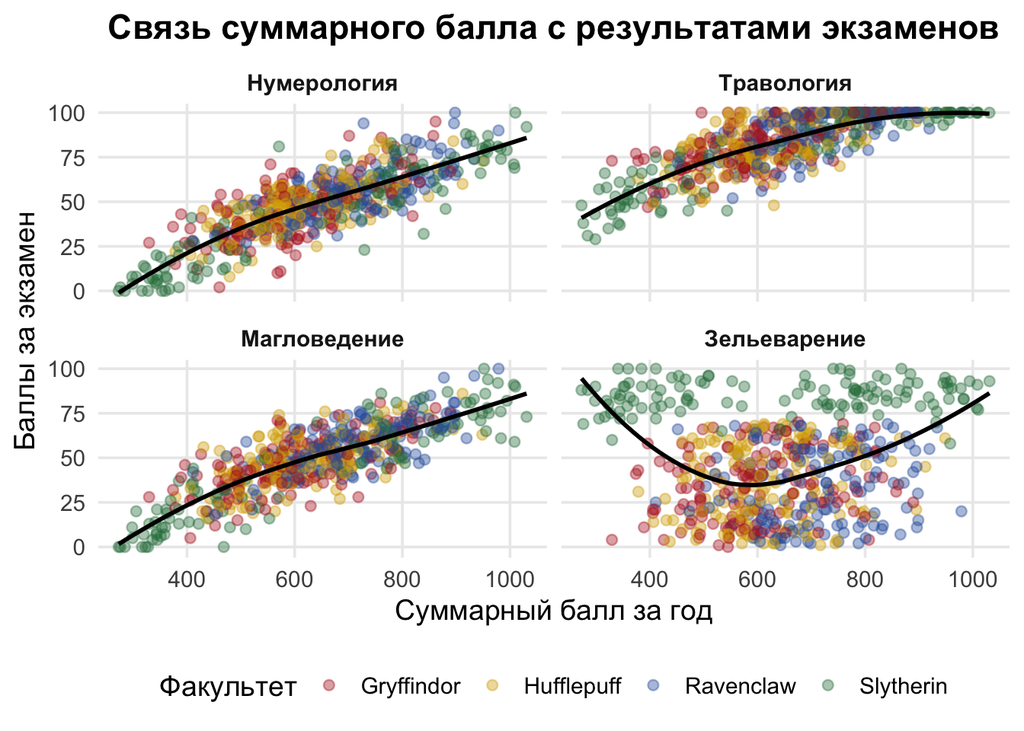

```r
hogwarts <- hogwarts |>
  mutate(
    total_score = rowSums(
      across(ends_with("exam")),
      na.rm = TRUE
    )
  )
exams <- c(
  "Herbology exam",
  "Muggle studies exam",
  "Arithmancy exam",
  "Potions exam"
)

long_exams <- hogwarts |>
  select(id, house, total_score, all_of(exams)) |>
  pivot_longer(
    cols = all_of(exams),
    names_to = "exam",
    values_to = "score"
  )

long_exams |>
  ggplot(
    aes(
      x = total_score,
      y = score,
      colour = house
    )
  ) +
  geom_point(alpha = 0.4, size = 2) +
  geom_smooth(
    aes(group = 1),
    method = "loess",
    span = 0.9,
    se = FALSE,
    colour = "black",
    linewidth = 1
  ) +
  facet_wrap(
    ~ exam,
    ncol = 2,
    labeller = as_labeller(c(
      "Herbology exam" = "Травология",
      "Muggle studies exam" = "Магловедение",
      "Arithmancy exam" = "Нумерология",
      "Potions exam" = "Зельеварение"
    ))
  ) +
  scale_colour_manual(
    values = c(
      "Gryffindor" = "#B32025",
      "Hufflepuff" = "#D7A900",
      "Ravenclaw" = "#2E5EAA",
      "Slytherin" = "#2F7D4A"
    ),
    name = "Факультет"
  ) +
  labs(
    title = "Связь суммарного балла с результатами экзаменов",
    x = "Суммарный балл за год",
    y = "Баллы за экзамен"
  ) +
  theme_minimal(base_size = 14) +
  theme(
    plot.title = element_text(
      face = "bold",
      hjust = 0.5
    ),
    strip.text = element_text(face = "bold"),
    panel.grid.minor = element_blank(),
    legend.position = "bottom"
  )
```

**Интерпретация:** Как и ожидалось, студенты сдающие хорошо экзамен, имеют и высокий балл за год (особенно это видно по Нумерологии и Магловедению). На травологии студенты сдают экзамен лучше всего, даже те у кого суммарный балл невысовкий - возможно экзамен легкий, или предмет дается просто. На зельеварении слизерин получает заметно выше балл, даже те, у кого низкий балл за год. Можно предположить, что либо Слизерин лучше знает этот предмет, чем остальные факультеты, либо преподаватель предзято оценивает. Интересно, что графики согласуются, если строить такой же график по result - вкладу ученика в общий балл факультета (?)

# Задание 6

Сравните распределение баллов за экзамен по прорицанию и за экзамен по защите от тёмных искусств. Сделайте это тремя разными способами. Под разными способами понимаются идеологически разные геомы или способы группировки. Не считаются разными способами изменения константных визуальных параметров (цвет заливки, размер фигур, другие чисто стилевые отличия) на сходных в остальном графиках.

Объедините графики так, чтобы итоговый график имел два столбца и две строки. Два графика должны стоять в верхней строке и занимать равную площадь. Третий график должен занимать нижнюю строку целиком. Проинтерпретируйте график.

[figure not shown]

```r
exam_data <- hogwarts |>
  select(
    `Divinations exam`,
    `Defence against the dark arts exam`
  ) |>
  pivot_longer(
    cols = everything(),
    names_to = "exam",
    values_to = "score"
  ) |>
  mutate(
    exam = recode(
      exam,
      "Divinations exam" = "Прорицания",
      "Defence against the dark arts exam" =
        "Защита от тёмных искусств"
    )
  )

p1 <- ggplot(
  exam_data,
  aes(x = score, fill = exam)
) +
  geom_histogram(
    aes(y = after_stat(density)),
    bins = 14,
    position = "identity",
    alpha = 0.5,
    color = "black"
  ) +
  scale_fill_manual(
    values = c(
      "Прорицания" = "#7B68A6",
      "Защита от тёмных искусств" = "#D97736"
    )
  ) +
  labs(
    title = "1. Гистограммы распределений",
    x = "Баллы за экзамен",
    y = "Плотность",
    fill = "Экзамен"
  ) +
  theme_minimal(base_size = 13) +
  theme(
    plot.title = element_text(face = "bold", hjust = 0.5),
    panel.grid.minor = element_blank(),
    legend.position = "bottom"
  )

p2 <- ggplot(
  exam_data,
  aes(x = score, colour = exam, fill = exam)
) +
  geom_density(alpha = 0.2, linewidth = 1) +
  scale_colour_manual(
    values = c(
      "Прорицания" = "#7B68A6",
      "Защита от тёмных искусств" = "#D97736"
    )
  ) +
  scale_fill_manual(
    values = c(
      "Прорицания" = "#7B68A6",
      "Защита от тёмных искусств" = "#D97736"
    )
  ) +
  labs(
    title = "2. Сравнение плотности распределений",
    x = "Баллы за экзамен",
    y = "Плотность",
    colour = "Экзамен",
    fill = "Экзамен"
  ) +
  theme_minimal(base_size = 13) +
  theme(
    plot.title = element_text(face = "bold", hjust = 0.5),
    panel.grid.minor = element_blank(),
    legend.position = "none"
  )

p3 <- ggplot(
  exam_data,
  aes(x = exam, y = score, fill = exam)
) +
  geom_boxplot(
    alpha = 0.8,
    width = 0.5,
    outlier.alpha = 0.4
  ) +
  scale_fill_manual(
    values = c(
      "Прорицания" = "#7B68A6",
      "Защита от тёмных искусств" = "#D97736"
    )
  ) +
  labs(
    title = "3. Сравнение медиан и разброса баллов",
    x = "Экзамен",
    y = "Баллы за экзамен"
  ) +
  theme_minimal(base_size = 13) +
  theme(
    plot.title = element_text(face = "bold", hjust = 0.5),
    panel.grid.minor = element_blank(),
    legend.position = "none"
  )

# Объединение графиков:
# два сверху, третий на всю ширину снизу
(p1 | p2) / p3 +
  plot_layout(heights = c(1, 1))
```

**Интерпретация:** … Баллы по экзамену прорицания ниже, чем за защиту от темных искусств - почти никто не получает высокий былл - пик расположен левее. Зато по защите от темных искусств большинство студентов получают либо высокий, либо низкий балл - 2 пика справа и слева. Такая же ситуация по медиане - на прорицании она гораздо ниже.

# Задание 7

Постройте диаграмму рассеяния (скаттерплот), где по осям отложены результаты экзаменов по заклинаниям и по древним рунам. На графике есть некоторая проблема. Если вам трудно её определить, возьмите подсказку: постройте скаттерплот по данным из файла `data/podskazka.csv`. По оси x отложите переменную `y`, по оси y — переменную `x`, а пределы оси y задайте от 200 до 500. Предложите и подкрепите визуализациями не менее трёх способов решить эту проблему.

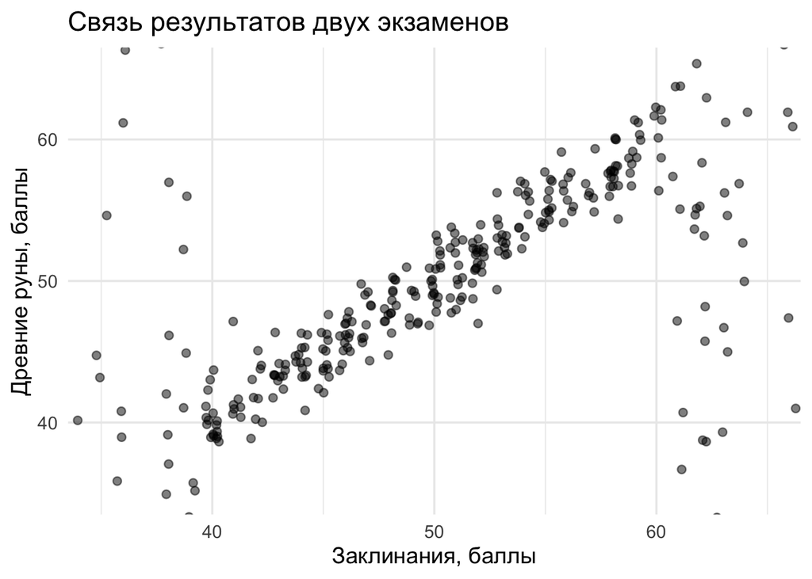

```r
ggplot(
  hogwarts,
  aes(
    x = `Charms exam`,
    y = `Study of ancient runes exam`
  )
) +
  geom_jitter(
    width = 0.3,
#    height = 0,
    alpha = 0.5,
    size = 2
  ) +
  scale_y_continuous(
    breaks = seq(0, 100, by = 10),
    minor_breaks = NULL
  ) +
  coord_cartesian(
    xlim = c(35, 65),
    ylim = c(35, 65)
  ) +
  labs(
    title = "Связь результатов двух экзаменов",
    x = "Заклинания, баллы",
    y = "Древние руны, баллы"
  ) +
  theme_minimal(base_size = 14)
```

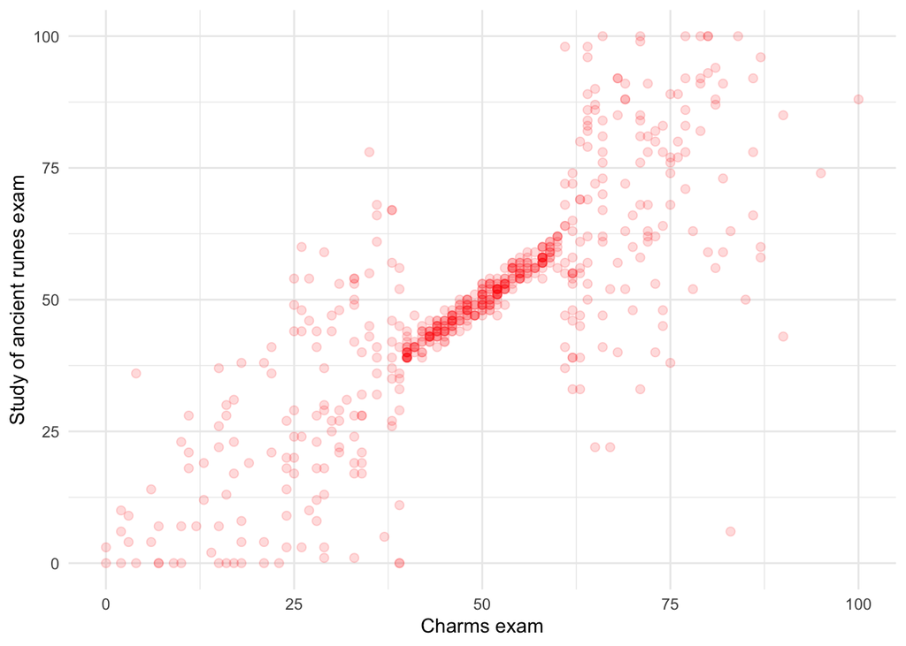

```r
ggplot(
  hogwarts,
  aes(
    x = `Charms exam`,
    y = `Study of ancient runes exam`
  )
) +
  geom_point(
    colour = "red",
    alpha = 0.15,
    size = 2
  ) +
  theme_minimal()
```

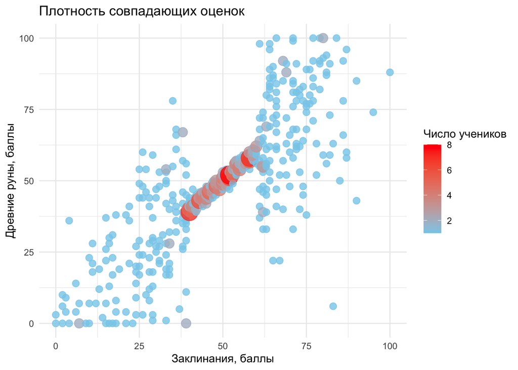

```r
ggplot(
  hogwarts,
  aes(
    x = `Charms exam`,
    y = `Study of ancient runes exam`
  )
) +
  geom_count(aes(colour = after_stat(n)), alpha = 0.8) +
  scale_colour_gradient(
    low = "skyblue",
    high = "red",
    name = "Число учеников"
  ) +
  scale_size_area(max_size = 8, guide = "none") +
  labs(
    title = "Плотность совпадающих оценок",
    x = "Заклинания, баллы",
    y = "Древние руны, баллы"
  ) +
  theme_minimal()
```

Используйте таблицу с баллами по неделям для первых 30 студентов, которую мы получили на занятии (`first_30`, конспект 2, раздел «Линии: `group`, спагетти, акцент, профиль (слайд 53)»). В ней пока нет столбца `bloodStatus`, а он понадобится для подписей. Постройте лайнплоты для всех студентов. Выделите при помощи пакета gghighlight студентов факультета Рейвенкло, на лейблах отразите их происхождение.

Линии студентов других факультетов покрасьте в нейтральный серый цвет и задайте его явно, а их толщину сделайте не больше трети стандартной. Проинтерпретируйте график.

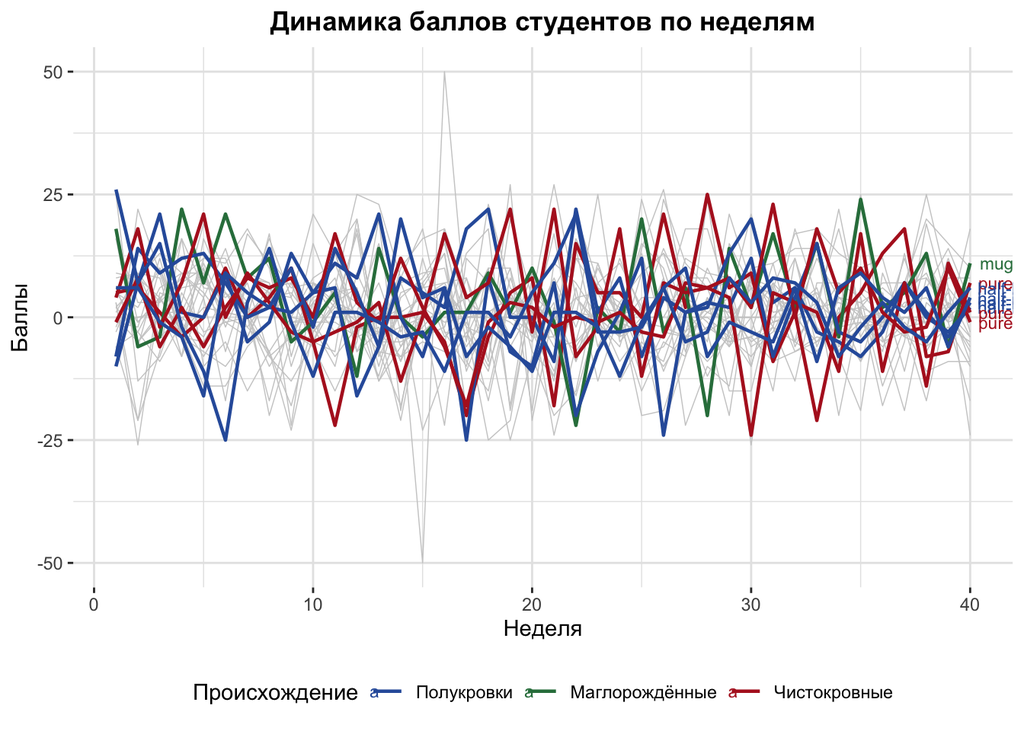

```r
weeks_long <- hogwarts |>
  select(id, house, bloodStatus, starts_with("week_")) |>
  pivot_longer(
    cols = starts_with("week_"),
    names_to = "week",
    values_to = "points"
  ) |>
  mutate(week = parse_number(week))

first_30 <- weeks_long |>
  filter(id <= 30)

library(gghighlight)

ggplot(
  first_30,
  aes(x = week, y = points, group = id)
) +
  geom_line(
    data = first_30 |> filter(house != "Ravenclaw"),
    colour = "grey80",
    linewidth = 0.25
  ) +
  geom_line(
    data = first_30 |> filter(house == "Ravenclaw"),
    aes(colour = bloodStatus),
    linewidth = 0.8
  ) +
  geom_text(
    data = first_30 |>
      filter(house == "Ravenclaw", week == max(week)),
    aes(
      label = bloodStatus,
      colour = bloodStatus
    ),
    hjust = -0.1,
    size = 3
  ) +
  scale_colour_manual(
    values = c(
      "pure-blood" = "#B32025",
      "half-blood" = "#2E5EAA",
      "muggle-born" = "#2F7D4A"
    ),
    labels = c(
      "pure-blood" = "Чистокровные",
      "half-blood" = "Полукровки",
      "muggle-born" = "Маглорождённые"
    ),
    name = "Происхождение"
  ) +
  labs(
    title = "Динамика баллов студентов по неделям",
    x = "Неделя",
    y = "Баллы"
  ) +
  theme(
    panel.background = element_rect(fill = "white"),
    plot.background = element_rect(fill = "white"),
    panel.grid = element_line(colour = "grey90"),
    plot.title = element_text(face = "bold", hjust = 0.5),
    legend.position = "bottom"
  )
```

**Интерпретация:** … Нет данных чтобы утверждать что происхождение как-то влияет на динамику баллов. Каждый студент не выделяется.

# Задание 9

Подробно (останавливаясь на каждом пункте, а не в общем) опишите, какие стороны графика и интерпретации (она приводится ниже) вы считаете верными и сделанными в соответствии с хорошими практиками, а какие — нет. Сделайте свой график, который отвечает на тот же исследовательский вопрос, но лишён технических и интерпретационных недостатков оригинала (если вы таковые нашли и упомянули).

График лежит в файле `images/task_2_4.png`:

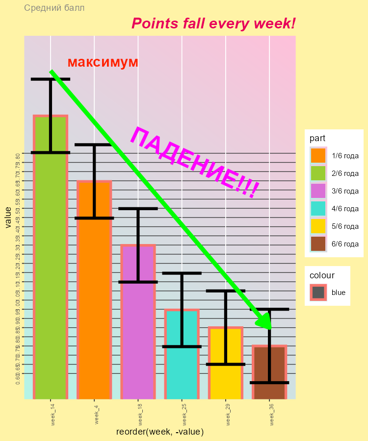

График к заданию 9

Интерпретация графика:

> В ходе исследования, проведенного в ФГБОУССО «Хогвартс» (далее Хогвартс) для оценки успешности образовательного процесса и психоэмоционального состояния участников вышеназванного процесса, были выявлены тревожные закономерности. А именно — при оценке среднего балла, полученного в течение недели совокупностью учащихся Хогвартса, была выявлена тенденция к резкому снижению данного показателя с течением времени. Так, в начале учебного процесса студенты набирали в среднем 2 балла (максимальный показатель). В последующие недели балл достоверно снижался, достигая минимальных значений к концу года (см. рис. 1). Мы полагаем, что данный процесс связан с ухудшением психологического состояния преподавателей означенного учебного заведения. Таким образом, в течение года они от мотивирующих мер положительного характера (добавление баллов за правильные ответы на занятиях и успехи во внеучебной деятельности) переходят к репрессивным действиям (учащающийся и увеличивающийся по модулю отъем баллов факультета за предполагаемые нарушения дисциплины, недостаточную, по мнению преподавателя, подготовку к занятию и пр.). Это вызывает снижение у учащихся мотивации к получению знаний, что вызывает следующий шаг снижения средненедельного балла — т.о., поведение педагогов вызывает своего рода circulus vitiosus.

> По итогам исследования и с учетом полученных результатов предлагается следующее: произвести замену профессорско-преподавательского состава с заменой педагогов, наиболее подверженных выгоранию в течение года (проявляющемуся в виде систематического снижения баллов студентам). Издать декрет о недопущении избыточного штрафования учащихся, начиная с 18-й недели учебного процесса до конца года. К нарушителям применять взыскания материально-магического характера. Объявить выговор с занесением в личное дело текущим представителям руководящего состава Хогвартса (далее дирекция).

**Разбор графика и интерпретации:** … 1) Название навязывает итерпретацию и эмоционально 2) Нельзя использовать гистограмму с усами - малоинформативно + столбчатая диаграмма не передает динамику 3) Недели упорядочены по величине показателя, а не по времени 4) Подпись value не объясняет, что измеряется 5) Значения по y показаны в очень мелких интервалах + график не объясняет смысл этих делений. 6) Цветовая палитра яркая и отвлекает внимание 7) Стрелка и надпись эмоционально мешают самостоятельно оценить данные 8) Стрелка также закрывает часть графика и визуально преувеличивает линейность снижения 9) Цветной фон, яркая сетка, толстые чёрные интервалы и декоративная стрелка мешают интерпретировать график 10) Подписи на y не читаемы 11) Усы подозрительно одинаковы

*Интерпретации* 1) “была выявлена тенденция к резкому снижению данного показателя с течением времени” - слишком категорично, на рисунке только 6 недель и ось x отсортирована не по времени 2) “студенты набирали в среднем 2 балла (максимальный показатель)” - данные показаны только за 6 недель - это не значит, что это максимум для года 3) “В последующие недели балл достоверно снижался, достигая минимальных значений к концу года” - не указаны результаты стат теста + самого графика недостаточно, чтобы утверждать статистическую значимость снижения 4) “процесс связан с ухудшением психологического состояния преподавателей” - график показывает баллы, но не измеряет психологическое состояние преподавателей. Он не позволяет установить причину снижения оценок 5) мотивация студентов также не измерена. Cам средний балл не доказывает, что причиной снижения является снижение мотивации 6) так же с оценкой поведения преподавателей (“поведение педагогов вызывает своего рода circulus vitiosus”) 7) снижение среднего балла не доказывает некомпетентность или выгорание преподавателей - не показывает, что нужно их менять 8) “недопущении избыточного штрафования учащихся, начиная с 18-й недели учебного процесса до конца года” - на графике не показано, почему именно 18я неделя должна стать границей 9) “К нарушителям применять взыскания материально-магического характера.” - не относится и интерпретации графика

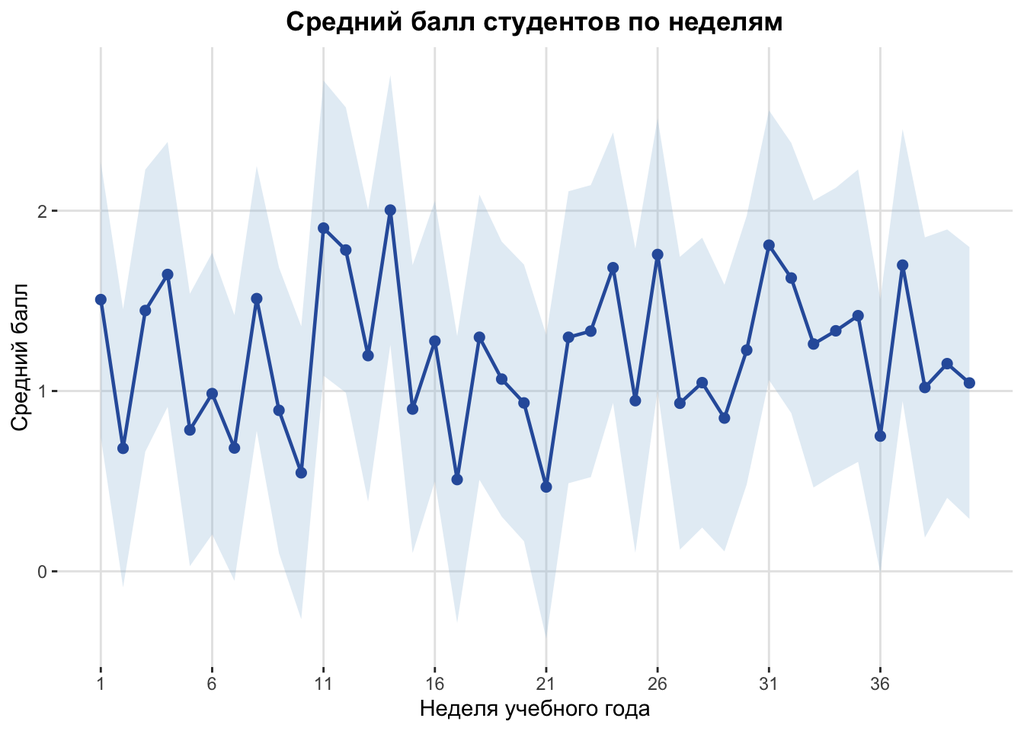

```r
weekly_means <- hogwarts |>
  select(starts_with("week_")) |>
  pivot_longer(
    cols = everything(),
    names_to = "week",
    values_to = "points"
  ) |>
  mutate(
    week = parse_number(week)
  ) |>
  group_by(week) |>
  summarise(
    mean_points = mean(points, na.rm = TRUE),
    n = sum(!is.na(points)),
    se = sd(points, na.rm = TRUE) / sqrt(n),
    .groups = "drop"
  )

ggplot(
  weekly_means,
  aes(x = week, y = mean_points)
) +
  geom_ribbon(
    aes(
      ymin = mean_points - 1.96 * se,
      ymax = mean_points + 1.96 * se
    ),
    fill = "#8FB9D9",
    alpha = 0.25
  ) +
  geom_line(
    colour = "#2E5EAA",
    linewidth = 0.8
  ) +
  geom_point(
    colour = "#2E5EAA",
    size = 2
  ) +
  scale_x_continuous(
    breaks = seq(1, 40, by = 5)
  ) +
  labs(
    title = "Средний балл студентов по неделям",
    x = "Неделя учебного года",
    y = "Средний балл"
  ) +
  theme(
    panel.background = element_rect(fill = "white"),
    plot.background = element_rect(fill = "white"),
    panel.grid.major = element_line(colour = "grey90"),
    panel.grid.minor = element_blank(),
    axis.title = element_text(size = 11),
    plot.title = element_text(
      face = "bold",
      hjust = 0.5
    )
  )
```

# Задание 10 (дополнительное)

Воспроизведите график максимально близко к оригиналу и проинтерпретируйте его. Постарайтесь максимально точно отразить каждый элемент.

Образец лежит в файле `images/task_10.png`:

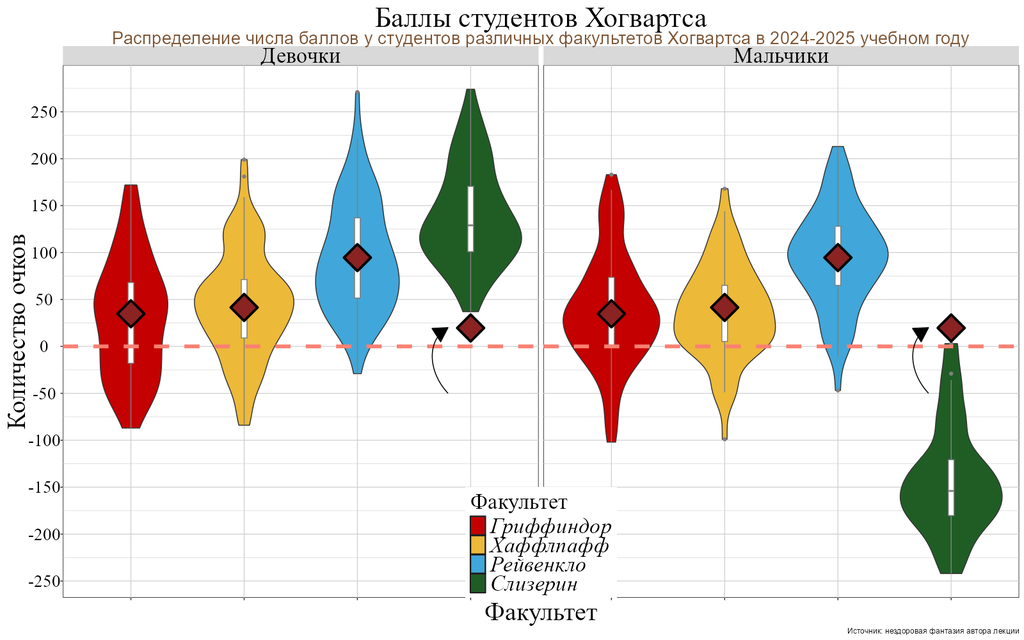

Образец к заданию 10